# Evaluating Shazam-Style Fingerprinting and CLAP Embeddings Under Audio Degradation

This notebook presents results from evaluating two fundamentally different audio retrieval methods — deterministic fingerprinting (Shazam-style) and neural audio embeddings (LAION-CLAP) — against the GTZAN dataset under a battery of real-world degradations.

## Structure

| Section | Topic |
| --- | --- |
| 1 | Dataset Overview |
| 2 | Shazam Fingerprinting Results |
| 3 | CLAP Genre Classification |
| 4 | CLAP Exact-Song Retrieval |
| 5 | Head-to-Head Comparison |

## Evaluation Setup

**Dataset**: GTZAN — 1,000 audio tracks (10 genres × 100 tracks × 30 s).

**Augmentations** — 17,982 files generated in two categories:

| Category | Types | Levels |
| --- | --- | --- |
| Additive Noise | White, Crowd, Street | SNR 0 / 10 / 20 dB |
| Musical Transforms | Pitch Shift Up, Pitch Shift Down, Lo-Fi Filter | 1 / 2 / 3 (semitones or severity) |

**Models evaluated**:

- **Shazam**: constellation-map fingerprinting, time-coherence matching. Full tracks indexed; 10 s random snippets queried.
- **CLAP General**: LAION-CLAP `630k-audioset-best.pt` — broad multi-domain training.
- **CLAP Music**: LAION-CLAP `music_audioset_epoch_15_esc_90.14.pt` — music-specialist fine-tune.

**Evaluation tasks**:

- *Genre classification*: logistic regression trained on clean CLAP embeddings, tested on augmented.
- *Exact-song retrieval*: cosine similarity search — does the augmented embedding rank its clean original first?
- *Shazam identification*: Top-1 match; reported as correct / false-positive / reject.

## 1. Dataset Overview

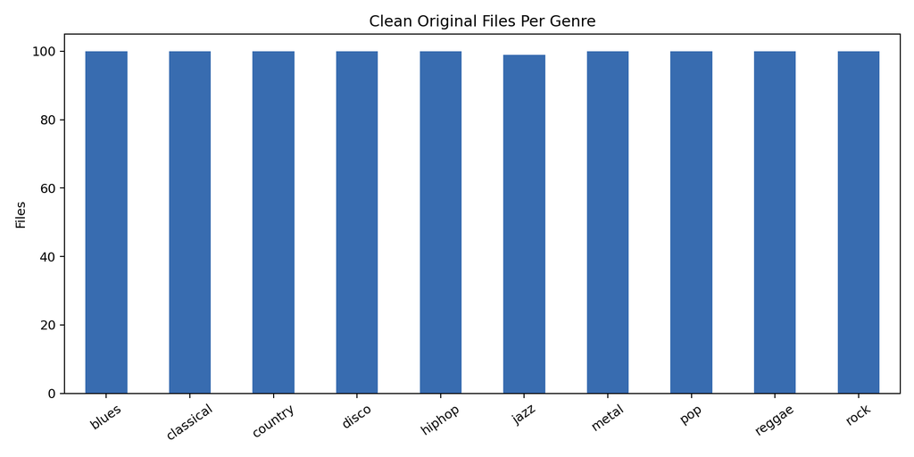

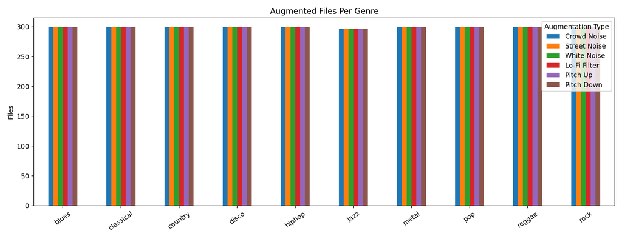

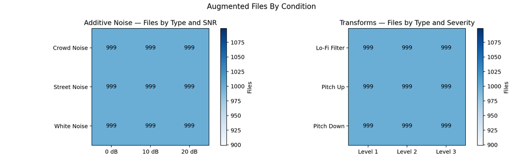

**Discussion**: The dataset is clean and balanced — no genre is over-represented, and every augmentation cell has equal coverage. This means accuracy numbers are directly comparable across conditions without correction for class imbalance.

## 2. Shazam Fingerprinting

Shazam's landmark hashing relies on the exact time-frequency coordinates of spectral peaks. A match requires enough (hash, time-offset) pairs to align in the time-coherence scorer. This architecture is highly optimised for the specific failure mode it was designed for — the "noisy bar" scenario — but has zero tolerance for pitch shift.

### 2.1 Overall outcome breakdown

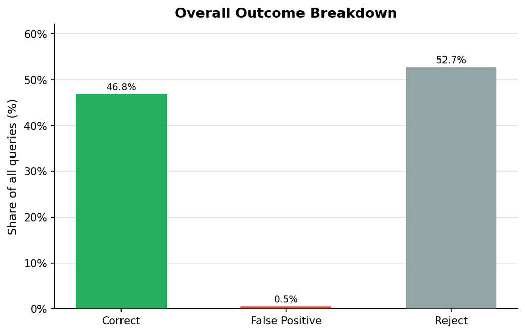

### 2.2 Noise vs transform split

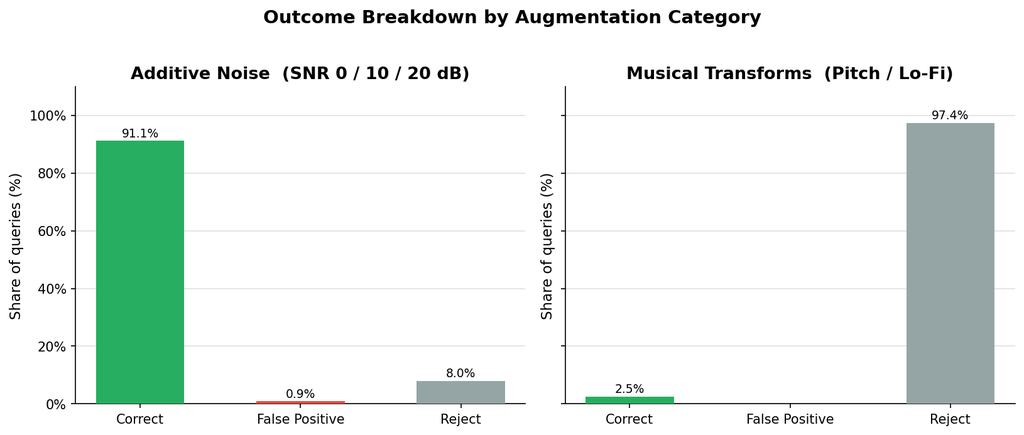

**Discussion**: The noise/transform split reveals two completely different systems in one. Under additive noise the system is robust. Under musical transforms it collapses — nearly every query is rejected. The asymmetry is stark.

### 2.3 Accuracy vs condition severity

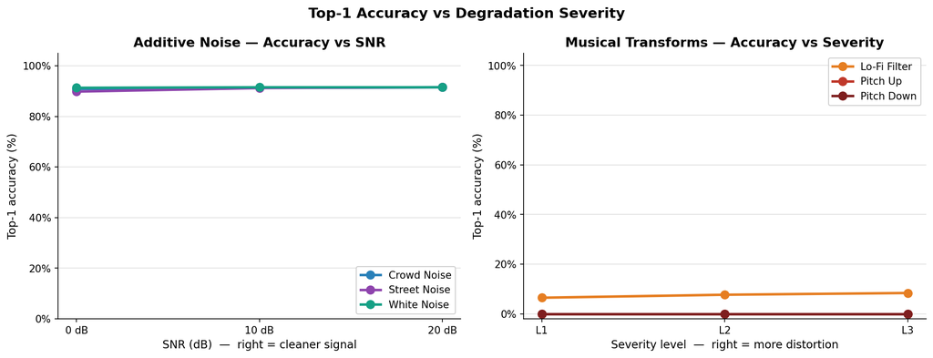

**Discussion**: Additive noise degrades accuracy very little, even at 0 dB SNR (equal signal and noise power). The lo-fi filter produces near-zero accuracy at all severity levels — the bandpass discards the high-frequency peaks that fingerprints depend on. Pitch shift is instant death at 1 semitone: every single query is rejected. Shazam's hashes encode exact frequency bins; a 1-semitone shift (~6%) moves every peak out of its bin.

### 2.4 Outcome composition per augmentation type

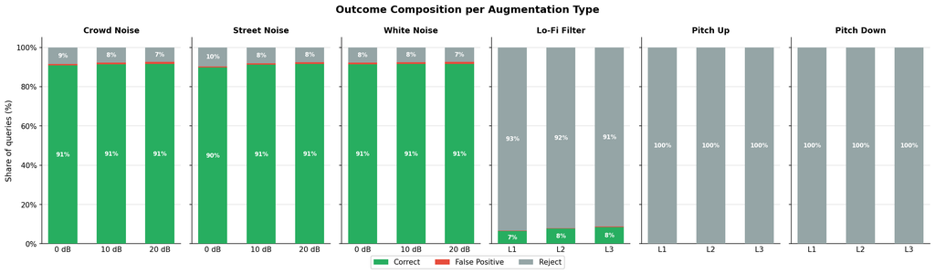

### 2.5 Per-genre accuracy

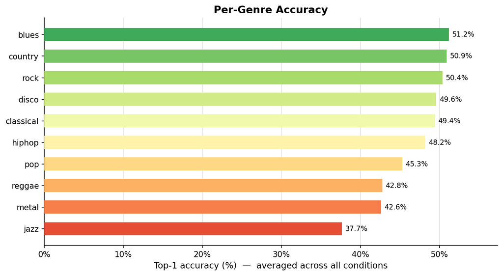

### 2.6 Per-genre accuracy by severity

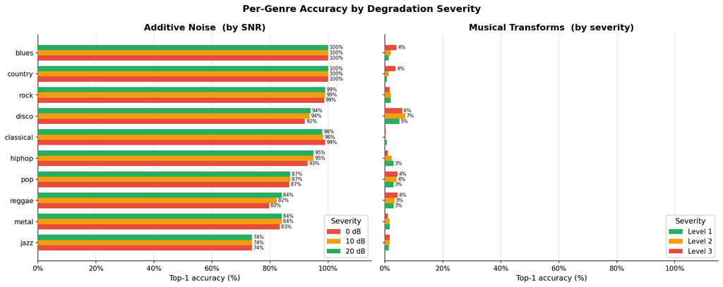

### 2.7 Genre × condition heatmap

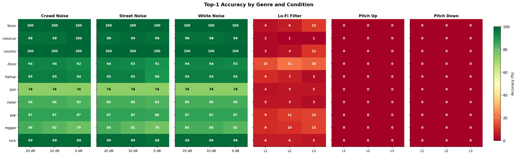

### 2.8 Identification latency

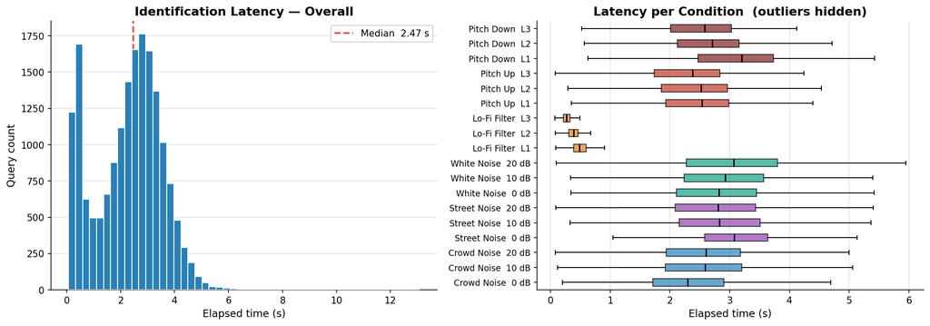

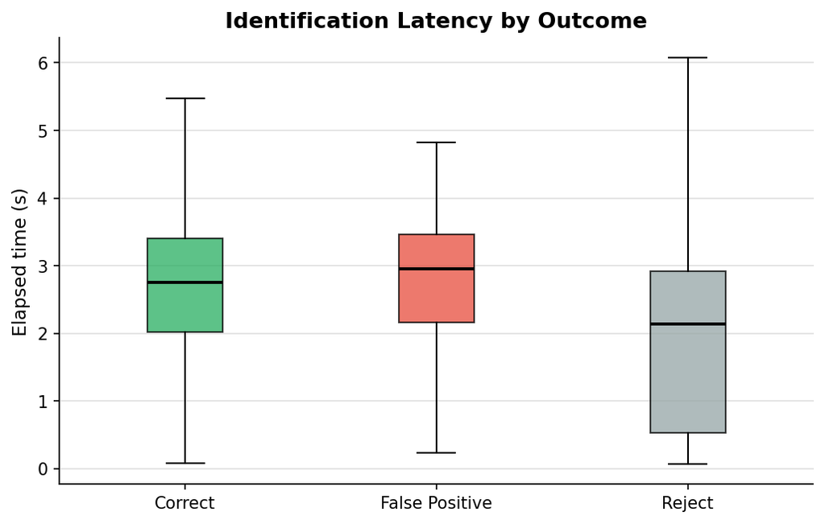

**Discussion**: Rejects are fast — the matcher exhausts its hash-lookup table quickly and bails when there are no coherent candidates. Correct matches take longer on average (more candidate pairs must be assembled and scored). The median latency of ~2–3 s for a 10 s snippet is consistent with the DSP pipeline processing the full query before lookup.

### 2.9 Score / confidence distributions

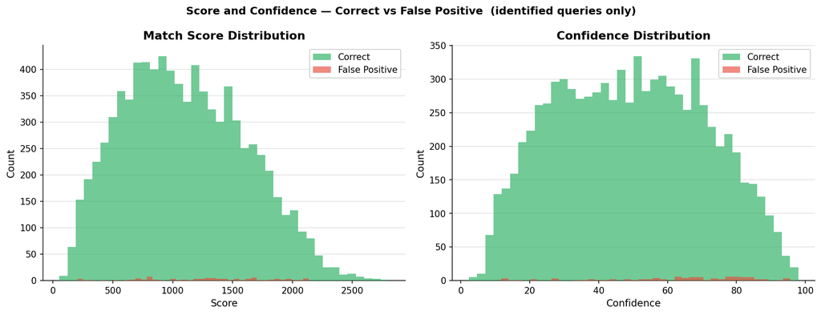

### 2.10 False-positive genre confusion

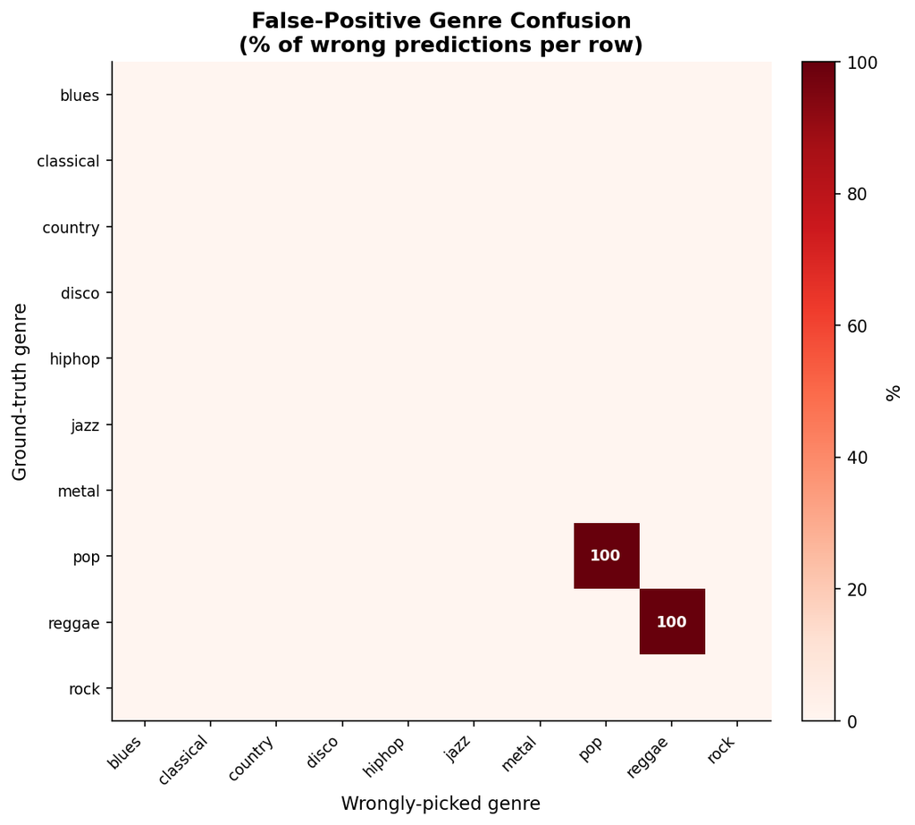

### 2.11 Summary table

| Condition | Level | Accuracy % | False Positive % | Reject % |
| --- | --- | --- | --- | --- |
| Crowd Noise | 0 dB | 90.8 | 0.7 | 8.5 |
| Crowd Noise | 10 dB | 91.3 | 0.9 | 7.8 |
| Crowd Noise | 20 dB | 91.5 | 1.1 | 7.4 |
| Street Noise | 0 dB | 89.8 | 0.5 | 9.7 |
| Street Noise | 10 dB | 91.2 | 0.8 | 8.0 |
| Street Noise | 20 dB | 91.5 | 0.9 | 7.6 |
| White Noise | 0 dB | 91.3 | 0.9 | 7.8 |
| White Noise | 10 dB | 91.5 | 1.0 | 7.5 |
| White Noise | 20 dB | 91.5 | 1.2 | 7.3 |
| Lo-Fi Filter | L1 | 6.5 | 0.2 | 93.3 |
| Lo-Fi Filter | L2 | 7.7 | 0.2 | 92.1 |
| Lo-Fi Filter | L3 | 8.4 | 0.3 | 91.3 |
| Pitch Up | 1 st | 0.0 | 0.0 | 100.0 |
| Pitch Up | 2 st | 0.0 | 0.0 | 100.0 |
| Pitch Up | 3 st | 0.0 | 0.0 | 100.0 |
| Pitch Down | 1 st | 0.0 | 0.0 | 100.0 |
| Pitch Down | 2 st | 0.0 | 0.0 | 100.0 |
| Pitch Down | 3 st | 0.0 | 0.0 | 100.0 |

## 3. CLAP Genre Classification

A logistic regression classifier is trained on the clean CLAP embeddings of all 1,000 GTZAN originals and then evaluated on augmented queries. This tests whether the embedding space preserves genre identity under degradation, regardless of whether the specific track can be retrieved. CLAP General and CLAP Music are evaluated separately.

### 3.1 Overall accuracy — noise

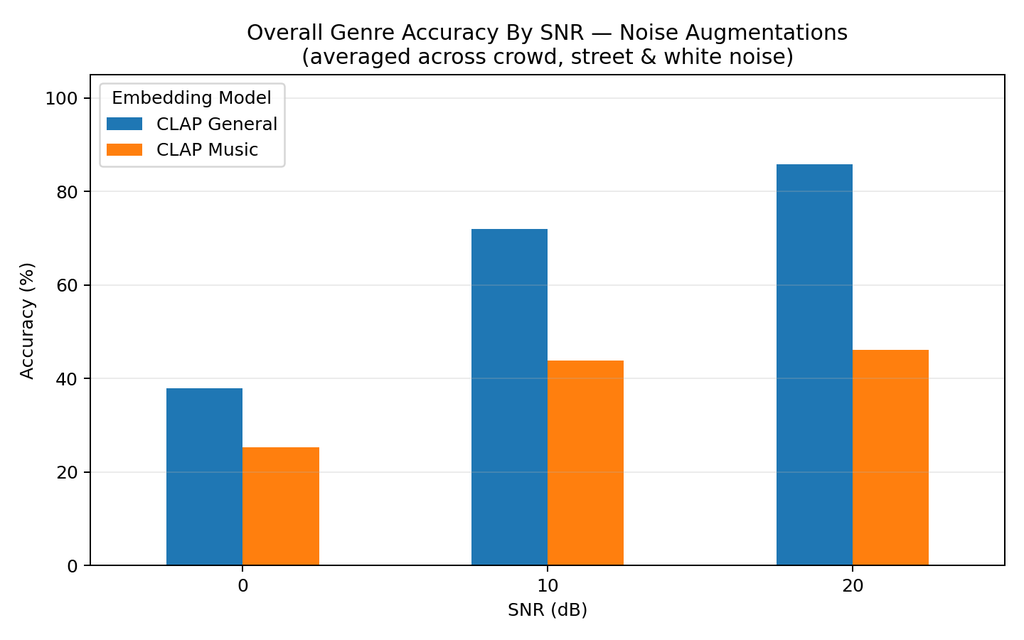

### 3.2 Overall accuracy — transforms

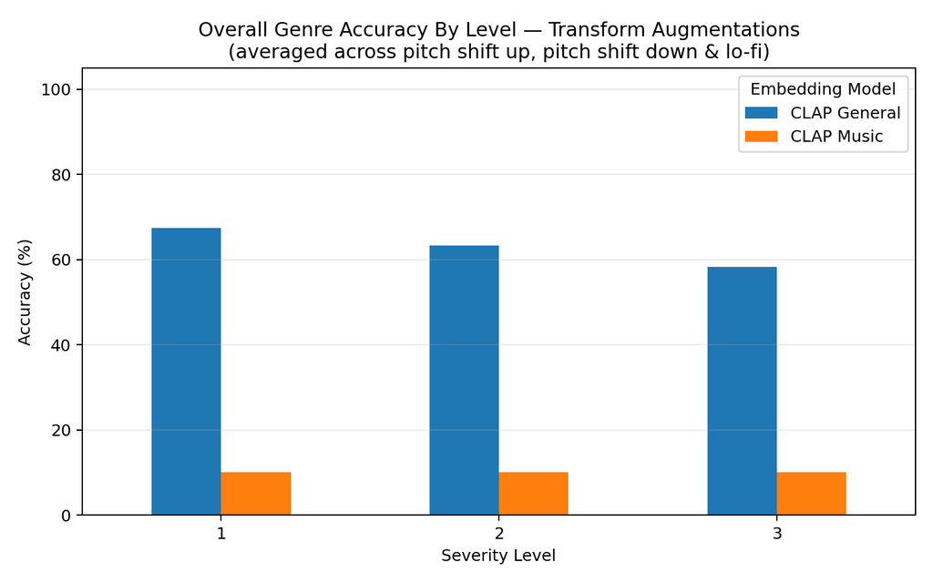

**Discussion**: CLAP Music collapses on transforms — pitch shift drives accuracy to approximately random chance (10% across 10 genres). CLAP General holds at 52–62% on pitch shift and 64–80% on lo-fi. The two models are not just quantitatively different; they are qualitatively different systems.

### 3.3 Per-genre accuracy by noise — CLAP General

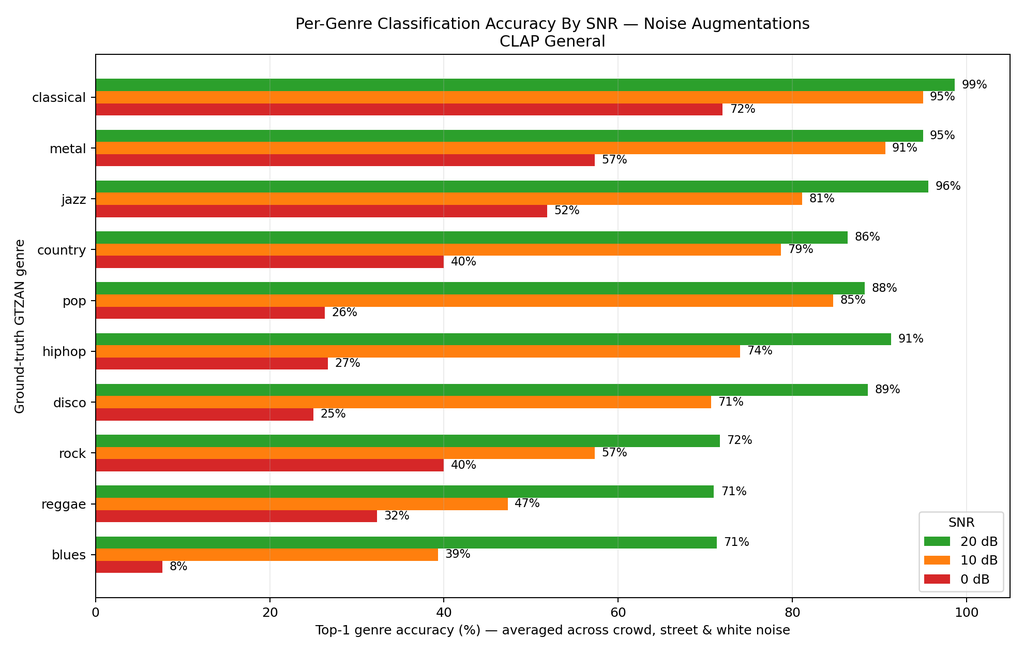

### 3.4 Per-genre accuracy by noise — CLAP Music

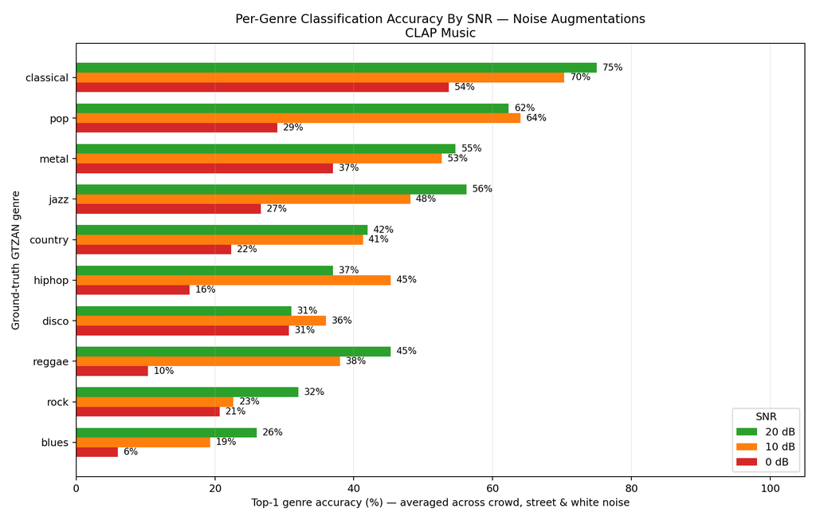

### 3.5 Per-genre accuracy by transform — CLAP General

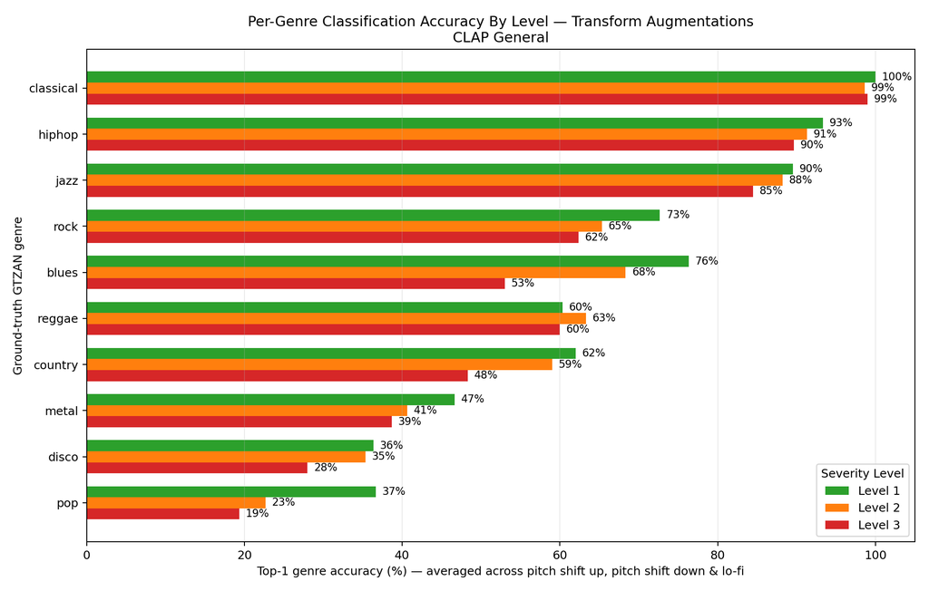

### 3.6 Per-genre accuracy by transform — CLAP Music

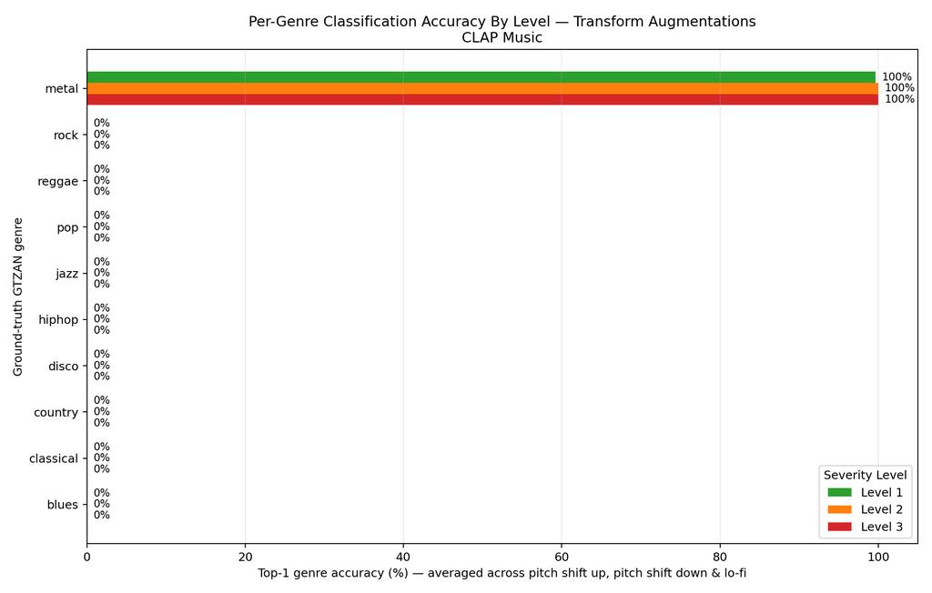

### 3.7 Accuracy by noise SNR and genre (heatmap)

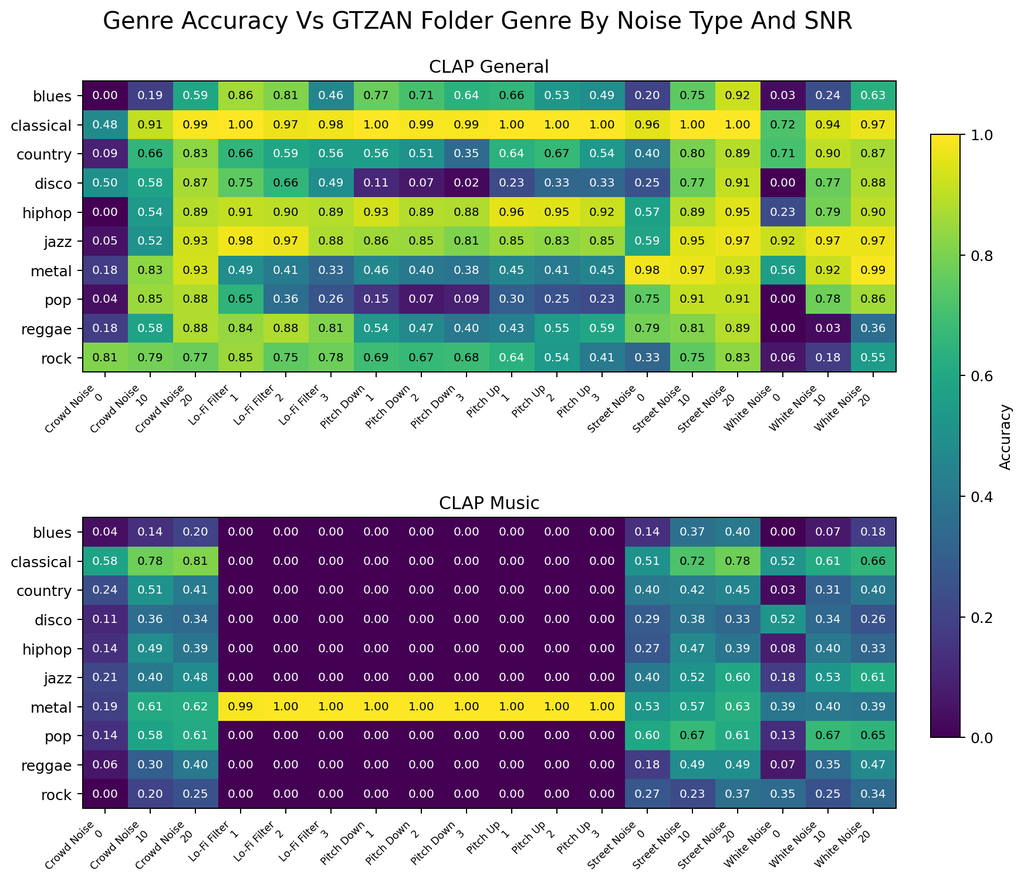

### 3.8 Confusion matrices

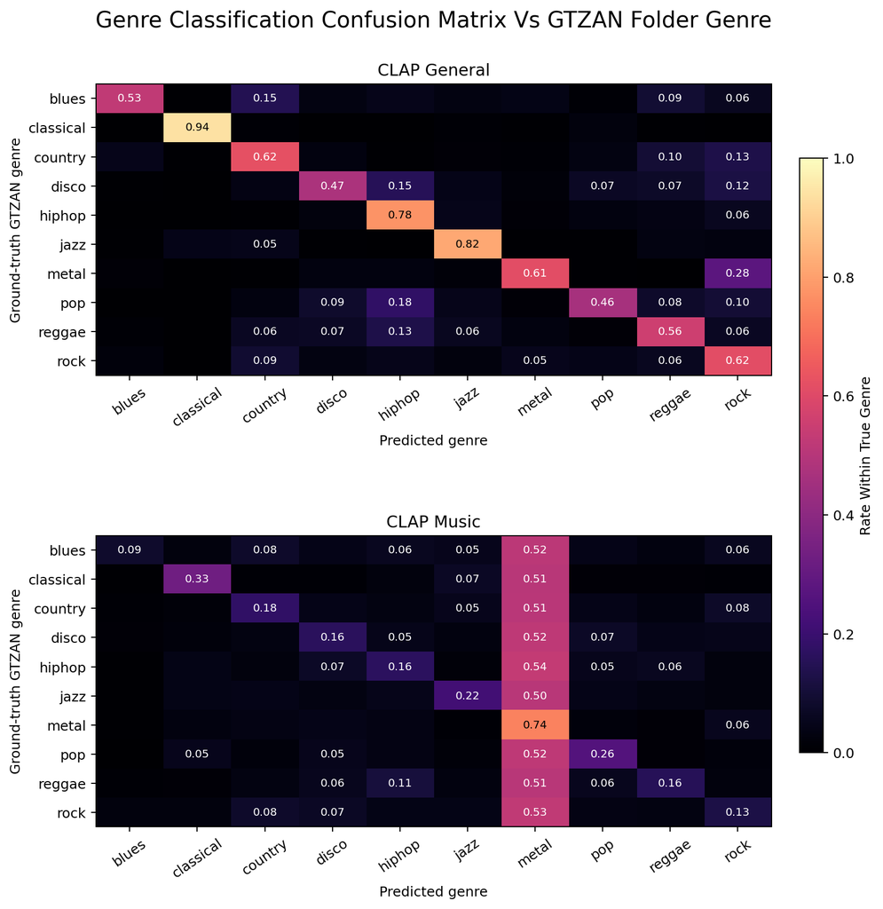

## 4. CLAP Exact-Song Retrieval

For each augmented query, we compute cosine similarity against all clean originals and ask: does the correct track rank first (Top-1)? Also reports Top-5 accuracy, genre-correct rate (right genre, wrong song), and `wrong_song_right_genre` rate (the fraction of retrievals that land in the right genre even when the exact song is wrong).

### 4.1 Top-1 exact retrieval — noise

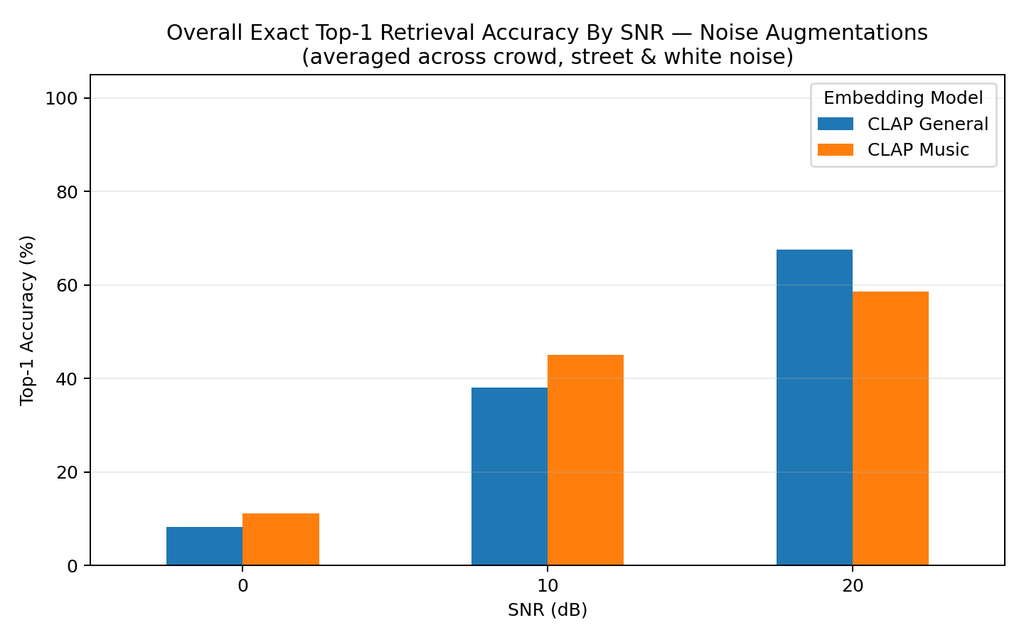

### 4.2 Top-1 exact retrieval — transforms

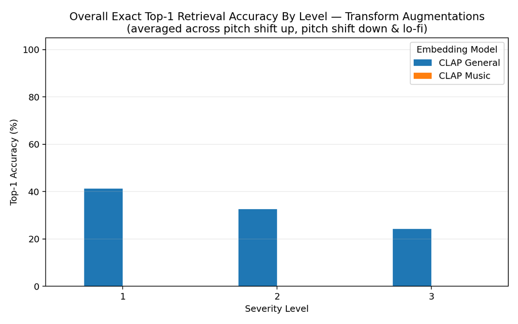

### 4.3 Top-1 by genre — noise — CLAP General

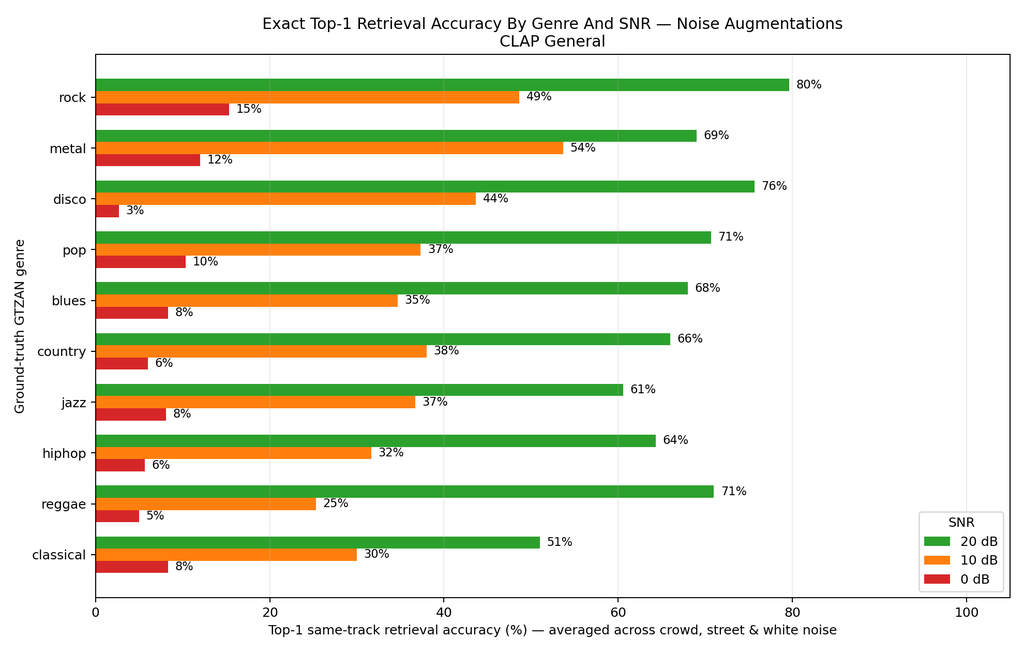

### 4.4 Top-1 by genre — noise — CLAP Music

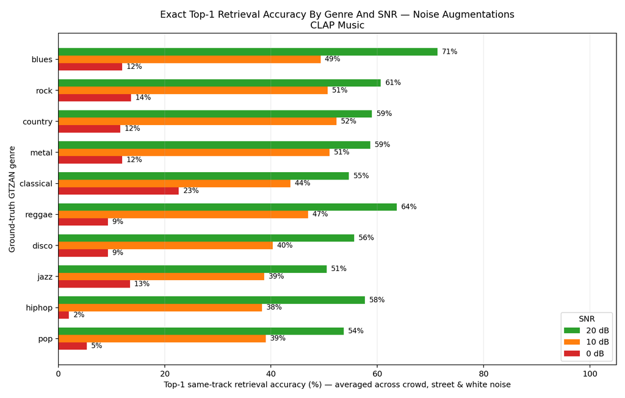

### 4.5 Top-1 by genre — transforms — CLAP General

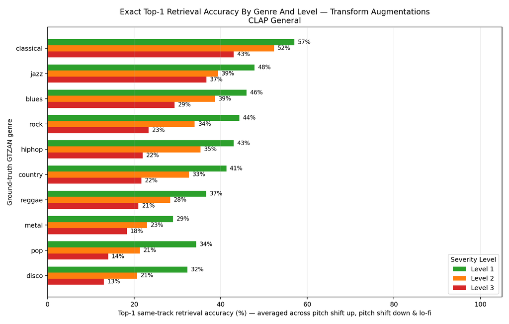

### 4.6 Top-1 by genre — transforms — CLAP Music

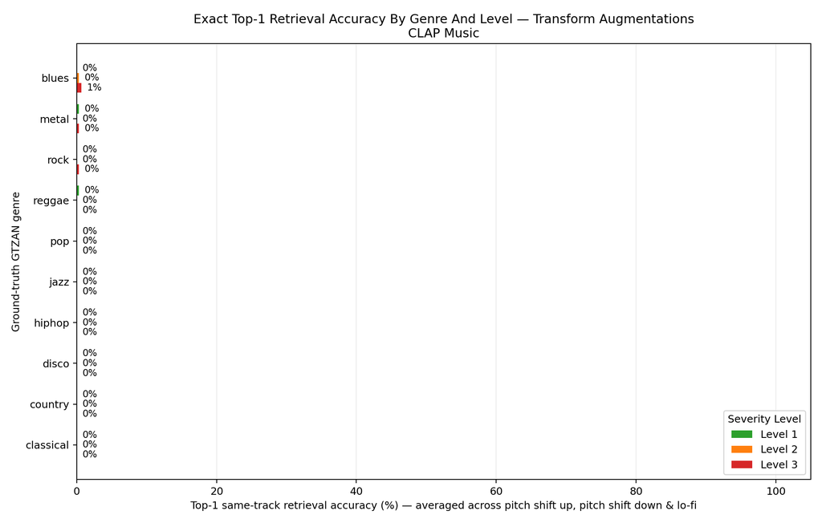

**Discussion**: CLAP General's transform retrieval by genre shows that pitch shift hurts all genres roughly equally — the model does not have a genre-specific pitch invariance. Lo-fi hurts genres with heavy high-frequency content (metal, rock) more than genres dominated by low-mid frequencies (blues, country). CLAP Music's transform panels are uniformly near-zero.

## 5. Head-to-Head Comparison

### 5.1 Summary

[output not shown]

### 5.2 Key findings

**Shazam is brittle to exact acoustic changes, robust to additive interference.** The landmark hashing algorithm was engineered for a specific use case — the noisy-bar problem — and it excels there, achieving ~91% accuracy even at 0 dB SNR. But it has zero tolerance for frequency shifts: a 1-semitone pitch shift moves every spectral peak out of its hash bin, destroying every fingerprint. The lo-fi bandpass filter removes the high-frequency peaks entirely. In both cases the matcher cannot assemble a coherent time-coherence window and rejects (fails safe). The false-positive rate remains under 1% even under failure conditions.

**CLAP General is the most robust system overall — not because it was designed to be, but because of breadth.** The 630k-audio-set general checkpoint was trained on environmental sounds, speech, and music together. This breadth means the embedding space is not tightly fitted to exact tonal relationships within music. When pitch shifts, the embedding drifts but does not collapse — it still lands in the right neighbourhood. The `wrong_song_right_genre_rate` of 38–46% on transforms confirms the model is doing semantic retrieval rather than exact matching: the wrong song, but the right genre.

**CLAP Music's specialist fine-tuning is catastrophically counterproductive for robustness.** The music-specialist checkpoint was fine-tuned to discriminate between musical characteristics — exactly the fine-grained tonal relationships that pitch shift destroys. When a query is pitch-shifted, its embedding moves to a region of the space that no training example occupies, and the model consistently predicts "metal" regardless of genre (a classic embedding collapse symptom). The cosine similarity between a pitch-shifted query and its clean original falls from ~0.99 to ~0.048 — the embedding is not just slightly wrong, it has moved to the opposite side of the space.

**Shared fatal weakness**: Shazam and CLAP Music both fail because they over-fit exact acoustic features. The paradox: the model purpose-built for music recognition is the worst at handling music-specific transforms.

### 5.3 Limitations and experimental bias

The augmented audio files are processed offline without codec re-encoding (no MP3/AAC artifacts) and without room impulse response. This gives Shazam a slight advantage in absolute accuracy versus real-world deployment. Since both methods are evaluated against the same augmented files, relative claims hold. See `notes.md` for mitigations if absolute accuracy numbers are needed.

CLAP evaluation is inherently easier than Shazam's because CLAP embeds the full augmented file (30 s), while Shazam queries with a random 10 s snippet. A fairer comparison would embed only a 10 s window for CLAP too — CLAP's numbers are therefore upper bounds relative to the Shazam evaluation protocol.